# disdRo

An R package for reading and handling disdrometer data

Santiago Beguería

2018-02-28

# Introduction

`disdRo` is an R package for reading and basic handling of raw disdrometer data.

As an example, one day of raw data from a Thies Klima LPM disdrometer are provided in directory tree under `extdata/rawDataThies`, in the package directory. You can find the location of those files with `system.file('extdata', 'rawDataThies', package='disdRo')`. Similarly, sample data from a OTT Parsivel2 disdrometer can be found in directory `extdata/rawDataParsivel`.

The `didRo` package contains some R functions for reading and handling rainfall drop size and velocity distribution (PSVD), or disdrometric matrix data, from the raw data files generated by Thies LPM or Parsivel optical disdrometers.

A bunch of Perl scripts are also included in directory `perl` for computing integrated variables from the raw data files. These scripts would eventually be ported into `R`.

Example data files are stored on `extdata`.

# Working with the PSVD matrix

We shall load the library to start:

```r
library(disdRo)
```

## Example with Thies LPM data

```r
f <- system.file('extdata', 'rawDataThies', package='disdRo')
files <- list.files(f, '.txt', full.names=TRUE, recursive=TRUE)
PSVD_T <- psvd_read(files, type='Thies')
dim(PSVD_T)
```

```
[1] 1439   22   20
```

Global aggregates for the whole period (one day, in this case) can be obtained easily from this array, for instance using `apply`. For instance, we can represent the distribution of particle size and velocities using bar plots:

```r
day_T <- apply(PSVD_T, c(2,3), sum)
head(day_T)
```

```
       0.1  0.3  0.5  0.7  0.9   1.2  1.6    2  2.4  2.8  3.2  3.8  4.6
0.1875 183 1242 4239 6694 6158  7804 4391 2401 1229  788  484  476  231
0.3125  17  166  584 1591 3781 14083 7655 2900 1687 1044  736 1039  515
0.4375   5   97  261  533  781  2999 3887 3133 1152  647  441  487  158
0.625    9   59  171  276  355  1031  769 2504 3242 2166 1143  906  157
0.875    1   17   26   57   53   114  119   99  163  526 1152 2108  355
1.125    0    4   11   13   19    39   44   60   48   35   78 1465 1151
       5.4 6.2  7 7.8 8.6 9.5 10.5
0.1875 107  27  9   7   0   0    0
0.3125 265 133 71  29  37   2    9
0.4375  56  15  7   0   0   0    0
0.625   31   8  2   0   0   0    0
0.875   26  12  1   0   0   0    0
1.125   75   7  2   0   0   0    0
```

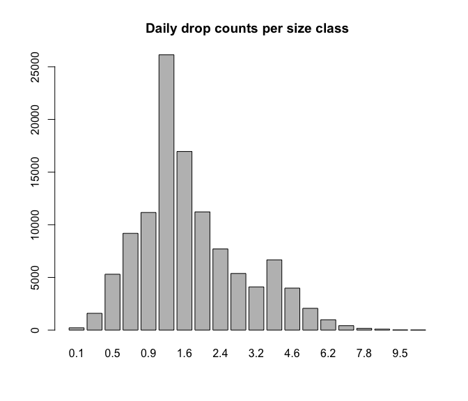

```r
barplot(colSums(day_T), main='Daily drop counts per size class')
```

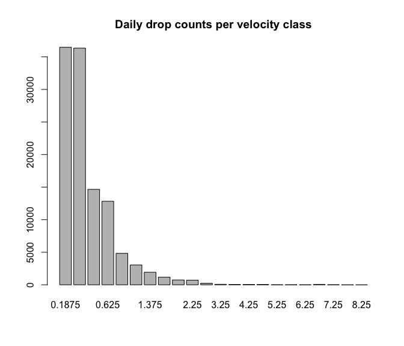

```r
barplot(rowSums(day_T), main='Daily drop counts per velocity class')
```

Or the more conventional PSVD logarithmic scatter:

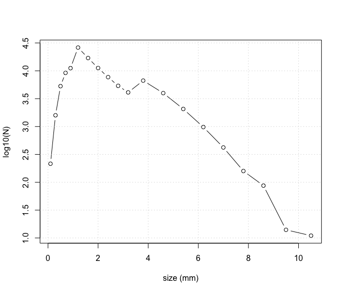

```r
plot(log10(colSums(day_T))~colnames(day_T), ylab='log10(N)', xlab='size (mm)', type='b')
grid()
```

Time aggregation:

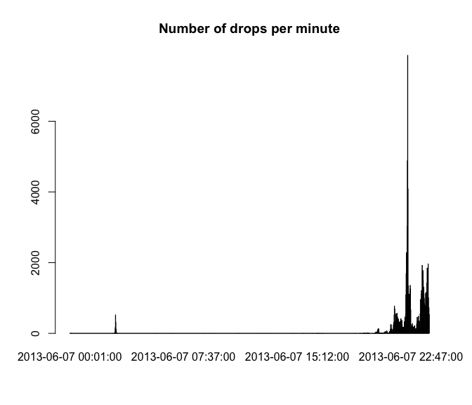

```r
time <- apply(PSVD_T, 1, sum)
barplot(time, main='Number of drops per minute')
```

The function `psvd_plot()` produces a drop count velocity vs. size plot from the PSVD data. The function interprets PSVD matrices from either Thies LPM or OTT Parsivel devices, being `Thies` the default option.

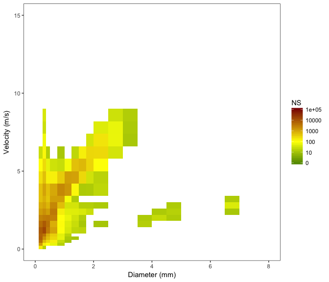

```r
psvd_plot(day_T, type='Thies')
```

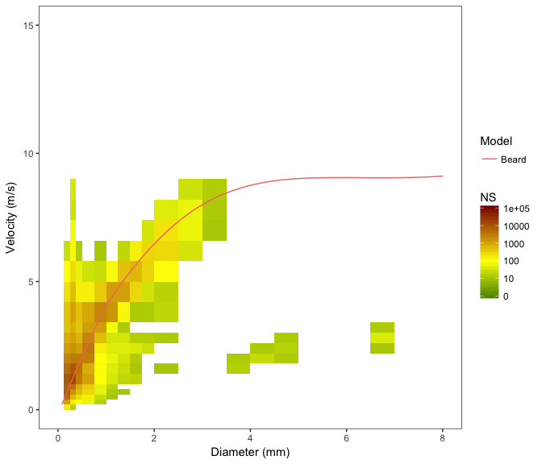

```r
psvd_plot(day_T, model='Beard')
```

The Beard model of terminal drop velocity is a physical approximation accounting for different factors such as viscous drag, drop oblateness, and others. The function implemented here is valid for drop sizes between 0.019 mm (19 µm) up to 7 mm. The Beard model is implemented by default assuming a standard atmosphere: P=101.325 kPa, T=288.15 K, and rho= 1.225 kg/m3, but other values can be provided for these parameters, since they affect the critical velocity of falling meteors. It is advisable, at least, to specify the altitude of the site where the data was acquired, because this will be used by the function to calculate the other factors, assuming a standard atmosphere. See, for instance, the different fall velocity models at sea level (the default, shown above) and at 2000 meter above sea level:

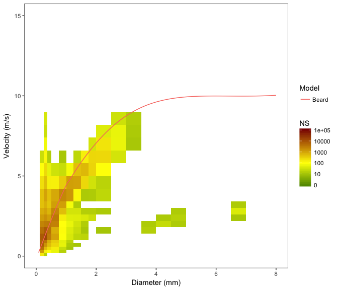

```r
psvd_plot(day_T, model='Beard', alt=2000)
```

The Beard model of particle fall velocity is implemented in function `psvd_model`. This function also contains the approximations by Atlas, Uplinger and Van Dijk, but these are limited to a shorter range of particle sizes and are less flexible with respect to variations from the standard atmosphere.

The size of the bins in the previous plot correspond to those of the raw matrix yielded by the disdrometer. Interpolated 2D desnity contour lines can be plotted on top by setting parameter `contour` to TRUE:

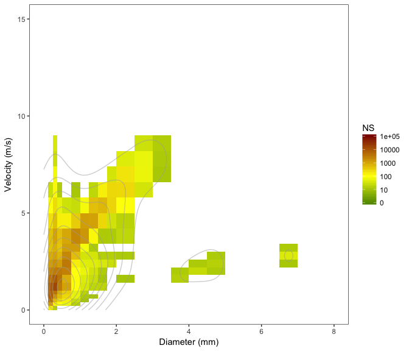

```r
psvd_plot(day_T, model=NA, contour=TRUE)
```

Finally, there is an option to produce the plots in black and white, setting theme=‘bw’.

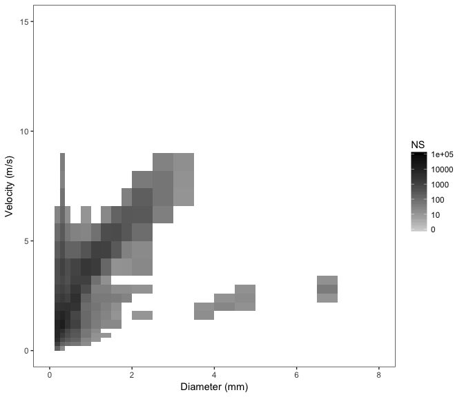

```r
psvd_plot(day_T, theme='bw')
```

## Example with Parsivel data

Note: So far, it is assumed that the data consists on the complete telegram is recorded, which may not correspond to the factory settings. Custom definition of the telegram has not been implemented yet.

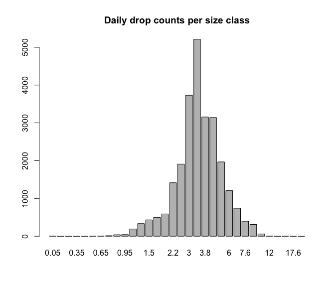

```r
f <- system.file('extdata', 'rawDataParsivel', package='disdRo')
files <- list.files(f, '.txt.gz', full.names=TRUE, recursive=TRUE)
PSVD_P <- psvd_read(files, type='Parsivel')

day_P <- apply(PSVD_P, c(2,3), sum)
barplot(colSums(day_P), main='Daily drop counts per size class')
```

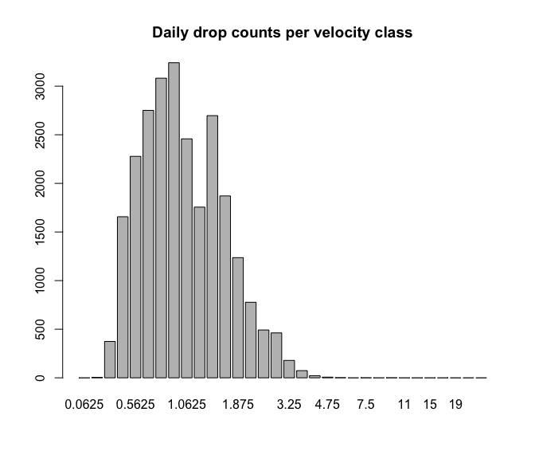

```r
barplot(rowSums(day_P), main='Daily drop counts per velocity class')
```

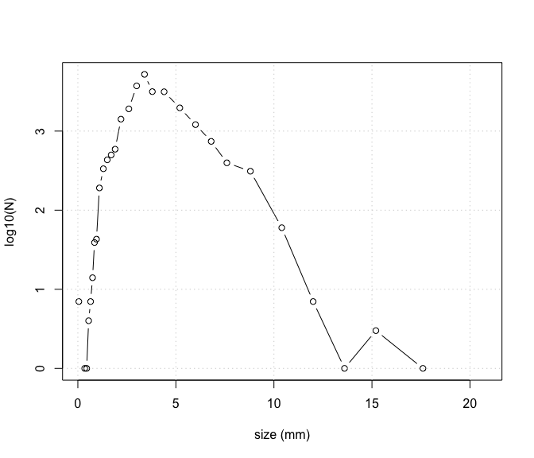

```r
plot(log10(colSums(day_P))~colnames(day_P), ylab='log10(N)', xlab='size (mm)', type='b')
grid()
```

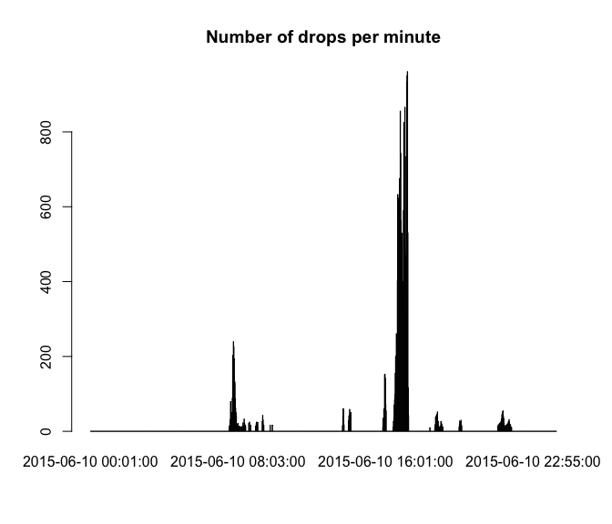

```r
time <- apply(PSVD_P, 1, sum)
barplot(time, main='Number of drops per minute')
```

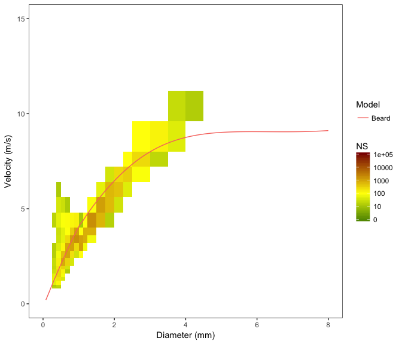

```r
psvd_plot(day_P, type='Parsivel', model='Beard')
```

## Filters

Disdrometer data are not devoid of errors. Especially, partial detections of particles falling at the edge of the laser beam (a.k.a. ‘margin fallers’, or ‘edge events’) are detected as smaller particles at super-critical velocity; and double detections of particles overlapping in time are detected as larger particles at sub-critical velocity. These events, which increase in frequency as the precipitation intensity increases, appear as deviations from the theoretical fall velocity model, and cause distortions and biases in the calculation of PSVD moments (‘integrated variables’).

Thus, the raw PSVD matrix is usually filtered to remove unlikely particle size and velocity combinations. Here, the function `psvd_filter` allows defining a filter that can be applied to PSVD data. It creates a matrix that is used as a mask in further calculations that involve using the PSVD matrix data.

PSVD filters can be produced for Thies or Parsivel disdrometers. Very small or large particles can be removed by setting particle size limits, and velocity limits can be set in a similar way. For instance, to produce a filter that will remove all particles smaller than 0.3 mm. In the image, red represents the data that will be filtered out:

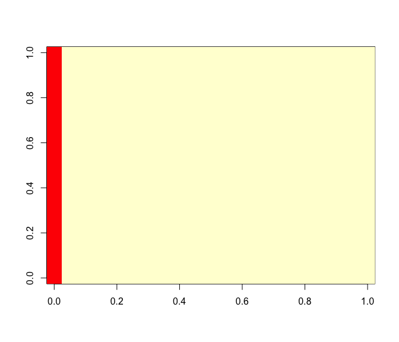

```r
flt <- psvd_filter(type='Thies', d=c(0.3,Inf))
image(flt)
```

Apart from setting limits to the particle size and velocity, the most interesting option consists on removing all the size and velocity combinations (bins) that are far from a theoretical fall velocity model. The model of Beard (1976) is used by default, although other models can be selected that are basically approximations to this model. The parameter `tau` determines the degree of filtering applied. Its default value is 0.5, implying that all bins with velocity 50% different from the theoretical model will be removed. All the atmospheric parameters available in the Beard model can also be set to build the filter:

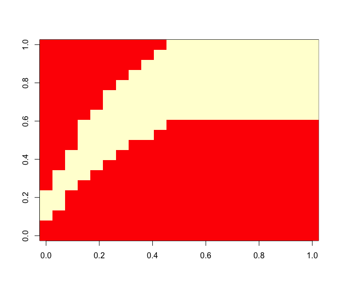

```r
flt <- psvd_filter(type='Thies', tau=0.5, alt=2000)
image(flt)
```

The filter can then be used in combination with the other functions. For instance, see the differences in the PSVD spectra of the Thies data, when the unlikely particles are filtered out (compare the following figure with the one obtained before):

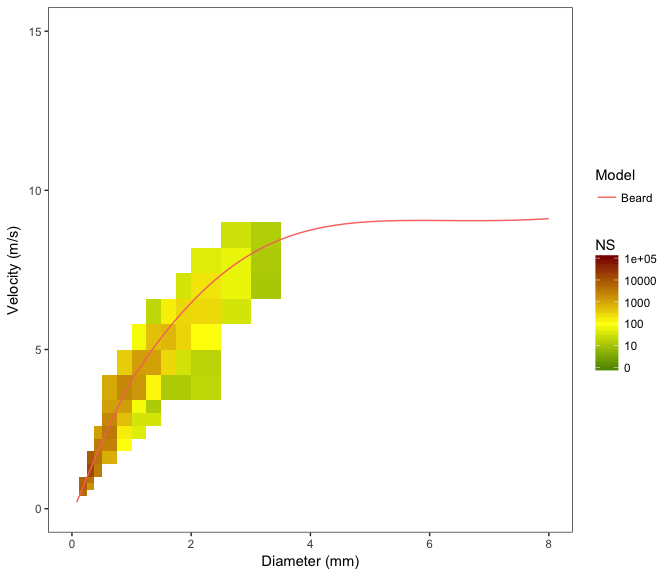

```r
psvd_plot(day_T, model='Beard', filter=flt, alpha=0)
```

## Particle size distribution

The funtion `psd_plot` produces a particle size distribution plot. The particle density (i.e., the number of drops per m^3 of air and mm of rain) is represented against the particle size, using a logaritmic Y axis.

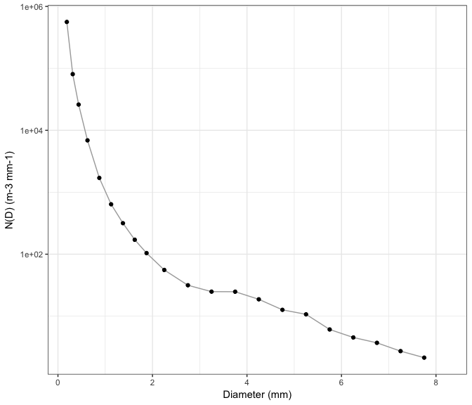

```r
psd_plot(day_T)
```

Compare the effect of filtering in the PSD plot:

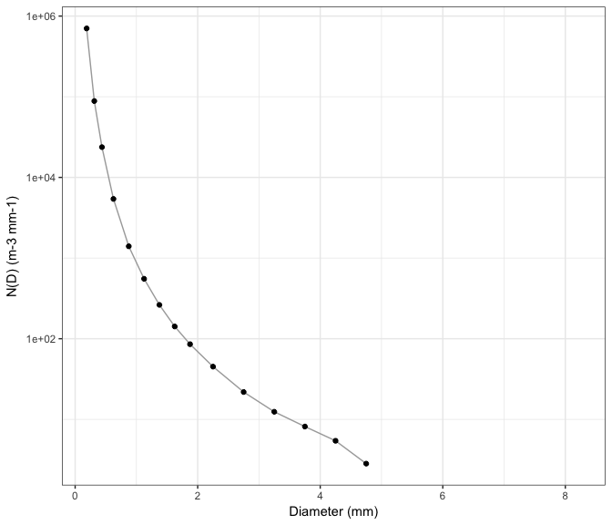

```r
psd_plot(day_T, filter=flt)
```

## Particle velocity distribution

The funtion `pvd_plot` produces a particle velocity distribution plot. The particle density (i.e., the number of drops per m^3 of air and mm of rain) is represented against the particle velocity.

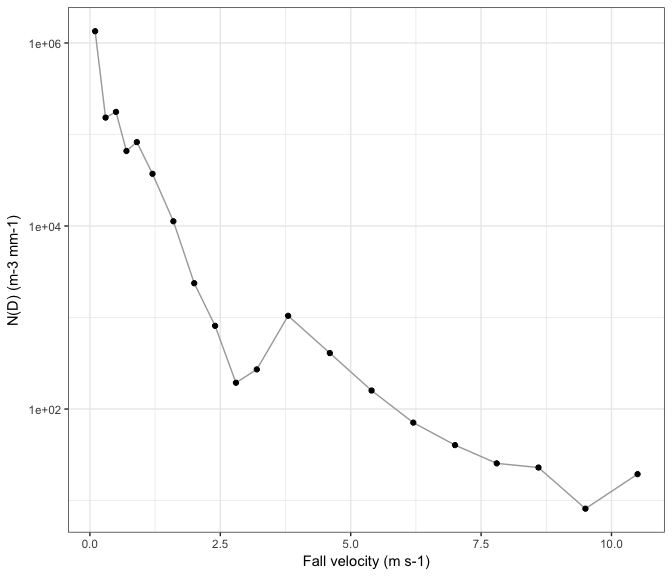

```r
pvd_plot(day_T)
```

Compare the effect of filtering in the PVD plot:

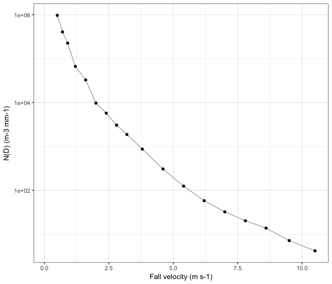

```r
pvd_plot(day_T, filter=flt)
```

## To do list

- All the files need to conform to the format expected from the disdrometer; there are frequent errors, especially on Parsivel files, that cause the function to fail.
- Possibility to define custom telegrams.
- Include indices (convectivity, etc).
- Implement fit to Gamma distribution (Braun & Upton).

# Working with the integrated variables

So far we have worked with the raw disdrometric matrix, or PSVD, but the disdrometers also offer a series of integrated variables which are calculated upon the raw matrix. These include the precipitation intensity and cumulative amounts, the kinetic energy released, the radar reflectivity, and others. The function `dsd_integrate()` enables automatic and fast computation of disdrometer integrated variables from raw disdrometer files. It also performs a quality control, and reports on several status variables recorded by the disdrometer.

Currently, this is done via an external Perl script, so you need to have Perl installed and working in your system. Beware: some users have reported issues for running the Perl script in Windows. It might be translated into a native R script in the future, if I find time to do it. The script `process.pl` can be found in the directory where the `disdRo` package was installed. The perl script can be used in stand-alone way as follows:

`perl process.pl directory outfile (middle|uniform|linear)`

The first argument invokes the Perl interpreter, the second argument points to the location of the script we want to run, the third argument points to the directory containing the disdrometer data, and the fourth argument provides a name of the output file to store the results. In addition, it is possible to choose between `middle`, `uniform`, and `linear`, which are different methods for estimating the distribution of drop sizes and velocities within the limits of the bins in which the PSVD matrix is divided (more on this later).

To use the `dsd_integrate()` function:

```r
?dsd_integrate
```

```
No documentation for 'dsd_integrate' in specified packages and libraries:
you could try '??dsd_integrate'
```

```r
f <- system.file('extdata', 'rawDataThies', package='disdRo')
int <- psvd_integrate(f)
summary(int)
```

```
  type          serial         time
 Thi:1440   Min.   :436   Min.   :2013-06-07 00:00:00
            1st Qu.:436   1st Qu.:2013-06-07 05:59:45
            Median :436   Median :2013-06-07 11:59:30
            Mean   :436   Mean   :2013-06-07 11:59:30
            3rd Qu.:436   3rd Qu.:2013-06-07 17:59:15
            Max.   :436   Max.   :2013-06-07 23:59:00

    seconds              synop             r                p
 Min.   :1.371e+09   Min.   : 0.00   Min.   : 0.000   Min.   :0.000000
 1st Qu.:1.371e+09   1st Qu.: 0.00   1st Qu.: 0.000   1st Qu.:0.000000
 Median :1.371e+09   Median : 0.00   Median : 0.000   Median :0.000000
 Mean   :1.371e+09   Mean   :10.05   Mean   : 0.421   Mean   :0.007016
 3rd Qu.:1.371e+09   3rd Qu.: 0.00   3rd Qu.: 0.000   3rd Qu.:0.000000
 Max.   :1.371e+09   Max.   :88.00   Max.   :33.980   Max.   :0.566300
                     NA's   :4       NA's   :4        NA's   :4
       m                   z                 e               mor
 Min.   :-1.000000   Min.   :-40.130   Min.   : 0.000   Min.   :       0
 1st Qu.: 0.000000   1st Qu.:  0.000   1st Qu.: 0.000   1st Qu.:       0
 Median : 0.000000   Median :  0.000   Median : 0.000   Median :       0
 Mean   :-0.002089   Mean   :  3.901   Mean   : 1.501   Mean   :  312231
 3rd Qu.: 0.000000   3rd Qu.:  0.000   3rd Qu.: 0.000   3rd Qu.:       0
 Max.   : 1.000000   Max.   : 58.420   Max.   :23.550   Max.   :24330000
 NA's   :4           NA's   :4         NA's   :4        NA's   :4
     r_meas            z_meas           e_meas     mor_meas
 Min.   : 0.0000   Min.   :-9.900   Min.   :0   Min.   :  677
 1st Qu.: 0.0000   1st Qu.:-9.900   1st Qu.:0   1st Qu.:99999
 Median : 0.0000   Median :-9.900   Median :0   Median :99999
 Mean   : 0.4399   Mean   :-4.936   Mean   :0   Mean   :90308
 3rd Qu.: 0.0000   3rd Qu.:-9.900   3rd Qu.:0   3rd Qu.:99999
 Max.   :33.3470   Max.   :41.600   Max.   :0   Max.   :99999
 NA's   :4         NA's   :4        NA's   :4   NA's   :4
      qual             tmp          rh          w           wd
 Min.   : 50.00   Min.   :0   Min.   :0   Min.   :0   Min.   :0
 1st Qu.:100.00   1st Qu.:0   1st Qu.:0   1st Qu.:0   1st Qu.:0
 Median :100.00   Median :0   Median :0   Median :0   Median :0
 Mean   : 98.81   Mean   :0   Mean   :0   Mean   :0   Mean   :0
 3rd Qu.:100.00   3rd Qu.:0   3rd Qu.:0   3rd Qu.:0   3rd Qu.:0
 Max.   :100.00   Max.   :0   Max.   :0   Max.   :0   Max.   :0
 NA's   :4        NA's   :4   NA's   :4   NA's   :4   NA's   :4
```

[output cut: 73 more lines]

```
 Min.   : 0.0000   Min.   : 0.0000   Min.   : 0.000000   Min.   :0
 1st Qu.: 0.0000   1st Qu.: 0.0000   1st Qu.: 0.000000   1st Qu.:0
 Median : 0.0000   Median : 0.0000   Median : 0.000000   Median :0
 Mean   : 0.5694   Mean   : 0.1555   Mean   : 0.008136   Mean   :0
 3rd Qu.: 0.0000   3rd Qu.: 0.0000   3rd Qu.: 0.000000   3rd Qu.:0
 Max.   :28.0270   Max.   :19.7783   Max.   :11.683723   Max.   :0
 NA's   :4         NA's   :4         NA's   :4           NA's   :4
    t_shift       now             err                ncol
 Min.   :0   Min.   : 0.00   Min.   :0.000000   Min.   :  0.0
 1st Qu.:0   1st Qu.:15.00   1st Qu.:0.000000   1st Qu.:524.0
 Median :0   Median :30.00   Median :0.000000   Median :524.0
 Mean   :0   Mean   :29.54   Mean   :0.002778   Mean   :522.5
 3rd Qu.:0   3rd Qu.:44.25   3rd Qu.:0.000000   3rd Qu.:524.0
 Max.   :0   Max.   :60.00   Max.   :1.000000   Max.   :524.0
 NA's   :4   NA's   :4
```

Explanation of the variables in the data frame:

| Num | Nombre | Descripción | Parsivel | Thies |
| --- | --- | --- | --- | --- |
| 1 | type | modelo del aparato | Si | Si |
| 2 | serial | número de serie del aparato | Si | Si |
| 3 | time | fecha y hora de la observación (POSIXct) | Si | Si |
| 4 | seconds | número de segundos desde 1970-01-01 00:00:00 | Si | Si |
| 5 | synop | SYNOP code 4677 | Si | Si |
| 6 | r | calculated rain intensity, mm h-1 | Si | Si |
| 7 | p | calculated precipitation amount, mm | Si | Si |
| 8 | m | calculated water content, g m3 | Si | Si |
| 9 | z | calculated radar reflectivity, dB mm6 m-3 | Si | Si |
| 10 | e | calculated kynetic energy, J m-2 mm-1 | Si | Si |
| 11 | mor | calculated MOR visibility, m | Si | Si |
| 12 | r_meas | measured rain intensity, mm h-1 | Si | Si |
| 13 | z_meas | measured radar reflectivity, dB mm6 m-3 | Si | Si |
| 14 | e_meas | measured kynetic energy, J m-2 mm-1 | Si | No |
| 15 | mor_meas | measured MOR visibility, m | Si | Si |
| 16 | qual | data quality, % | No | Si |
| 17 | tmp | air temperature, ºC | No | Opt |
| 18 | rh | relative air humidity, % | No | Opt |
| 19 | w | wind velocity, m/s | No | Opt |
| 20 | wd | wind direction, º | No | Opt |
| 21 | np_meas | measured number of particles detected (-) | Si | Si |
| 22 | np | number of particles detected (-) | Si | Si |
| 23 | lcurrent | current throught the laser |  |  |
| 24 | ocontrol |  |  |  |
| 23 | power | sensor power supply (V) | Si | Si |
| 24 | status | sensor status code (see table) | Si | Si |
| 25 | tmp_int | internal (sensor) temperature (ºC) | Si | Si |
| 25 | d10 | drop diameter, 10 percentile (mm) | Si | Si |
| 25 | d25 | drop diameter, 25 percentile (mm) | Si | Si |
| 26 | d50 | drop diameter, 50 percentile (mm) | Si | Si |
| 27 | d75 | drop diameter, 75 percentile (mm) | Si | Si |
| 27 | d90 | drop diameter, 90 percentile (mm) | Si | Si |
| 28 | dmean | average drop diameter (mm) | Si | Si |
| 29 | v10 | drop velocity, 10 percentile (m/s) | Si | Si |
| 29 | v25 | drop velocity, 25 percentile (m/s) | Si | Si |
| 30 | v50 | drop velocity, 50 percentile (m/s) | Si | Si |
| 31 | v75 | drop velocity, 75 percentile (m/s) | Si | Si |
| 29 | v90 | drop velocity, 90 percentile (m/s) | Si | Si |
| 32 | vmean | average drop velocity (m/s) | Si | Si |
| 33 | nd1 | numer density of 1st diameter class (m-3 mm-1) | Si | Si |
| 33 | t_shift | telegram time shift (s) | Si | Si |
| 34 | nrow | telegram line number | Si | Si |
| 35 | err | error status code (see table) | Si | Si |
| 36 | ncol | number of telegram fields | Si | Si |

An NA value is obtained if the variable does not exist in the telegram.

List of the sensor status codes:

| Code | Parsivel |
| --- | --- |
| 0 | Sensor OK |
| 1 | Sensor requires cleaning, but data are still OK |
| 2 | Sensor requires cleaning, data might be wrong |
| 3 | Laser damaged |

| Code | Thies |
| --- | --- |
| 0 | Sensor OK |
| 1 | Sensor damaged |

List of the error codes:

| Code | Description |
| --- | --- |
| 0 | No error |
| 1 | There are no data for that minute (NA) |
| 2 | Saturation (more than 999 drops) in the DSVD matrix (Thies) |
| 3 | Strange characters in the SYNOP code field |
| 4 | Strange characters in rain intensity field |
| 5 | 9999.999 in rain intensity field |
| 6 | The telegram only contains ‘OK’ o ‘Version’ (possible restart of Parsivel?) |
| 7 | There are strange characters somewhere in the telegram |

It is easy to plot the different variables:

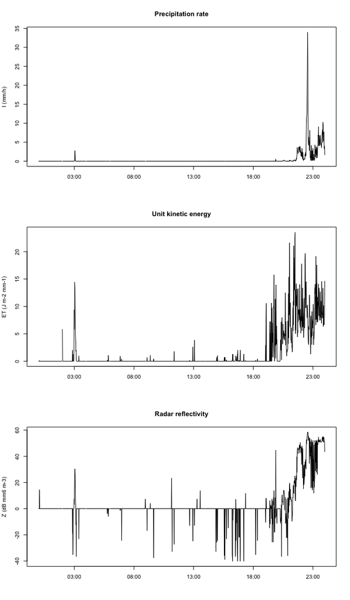

```r
par(mfrow=c(3,1))
plot(int$r~int$time, type='l', xlab='', ylab='I (mm/h)',
     main='Precipitation rate')
plot(int$e~int$time, type='l', xlab='', ylab='ET (J m-2 mm-1)',
     main='Unit kinetic energy')
plot(int$z~int$time, type='l', xlab='', ylab='Z (dB mm6 m-3)',
     main='Radar reflectivity')
```

The output of `dsd_integrate()` contains the integrated variables computed from the raw PSVD matrix, but also the same variables computed internally by the disdrometer and reported in the telegram (if they exist). These are distinguished by the suffix `_meas`.

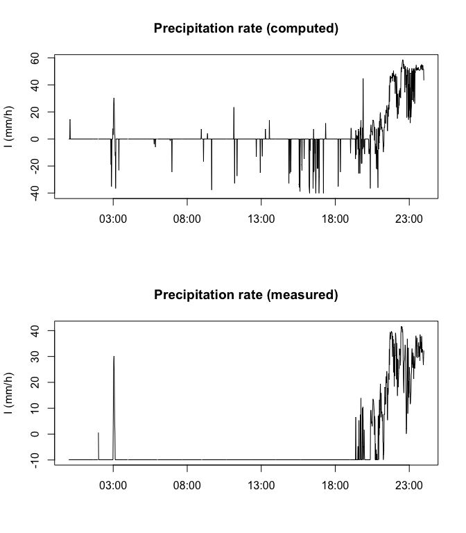

```r
par(mfrow=c(2,1))
plot(int$z~int$time, type='l', xlab='', ylab='I (mm/h)',
     main='Precipitation rate (computed)')
plot(int$z_meas~int$time, type='l', xlab='', ylab='I (mm/h)',
     main='Precipitation rate (measured)')
```

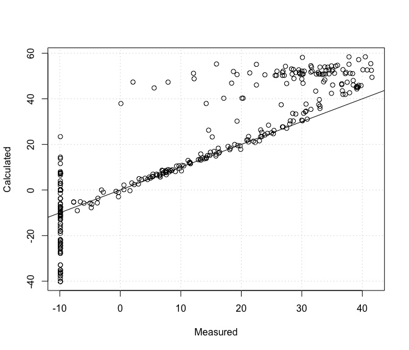

```r
par(mfrow=c(1,1))
plot(int$z~int$z_meas, ylab='Calculated', xlab='Measured')
grid()
abline(0,1)
```

By converting the output object (a `data.frame`) to a temporal series object of class `zoo`, it is easy to perform operations using the time as an index variable, for instance extracting a specific event for which we know the starting and ending times:

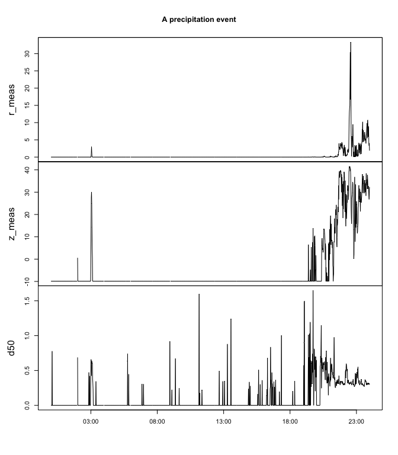

```r
library(zoo)
int <- zoo(int[,-c(1:3)], int$time)

event <- window(int, start='2013-06-07 28:00:00', end='2013-06-07 23:59:00')
plot(event[,c('r_meas','z_meas','d50')], type='l',
     xlab='', main='A precipitation event')
```

The computation of particle size and velocity percentiles (d25, d50, d75, v25, v50 and v75) is shomewhat triky due to the binned character of the PSVD matrix. Since all that is known is the number of particles detected within a range of particle sizes or velocities, in order to compute size and velocity percentiles there is a need to assign those particles specific values of size and velocity. The easiest option would be to assing the mean value of the bin to all the particles belonging to that class (see figure). This is the default option for the argument on function `dsd_integrate()`, equivalent to setting `interp='middle'`.

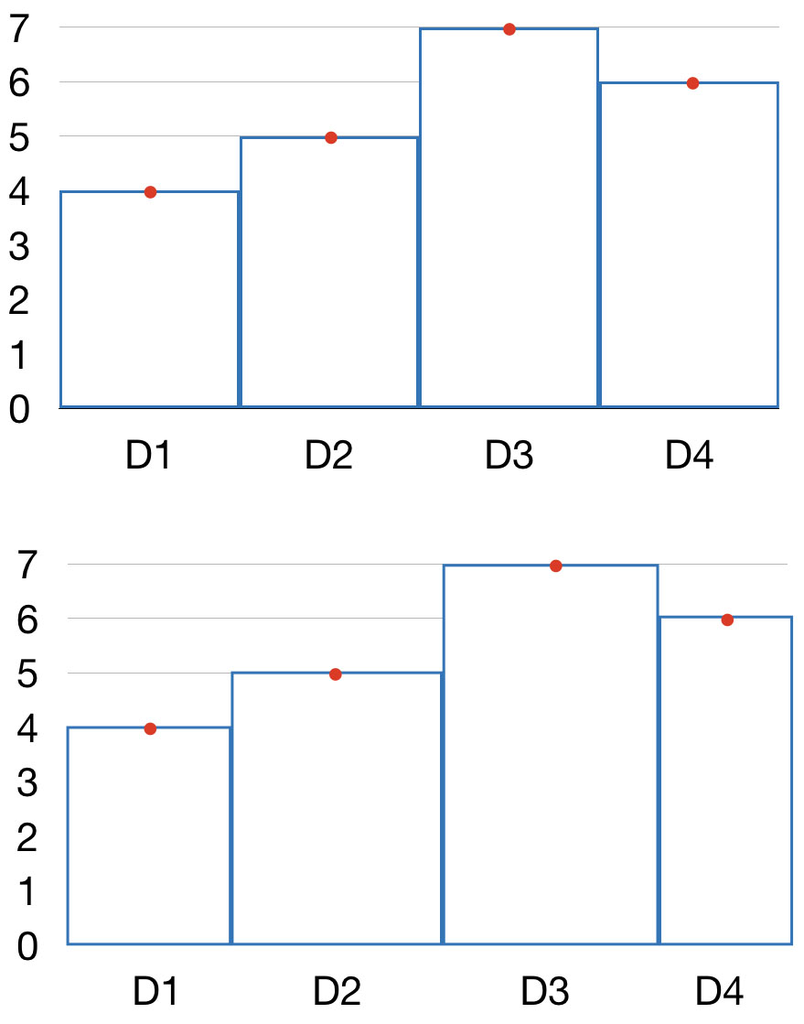

This, however, leads to issues when two different bin configurations are compared, for instante when comparing the output of two different disdrometer types (such as Thies LPN and OTT Parsivel). In order to get a better approximation to the size and velocity quantiles, two interpolation methods have been used for de-binning the information on the PSVD matrix. The first option, corresponding to setting `interp='uniform'`, is a random distribution of the detected particles over the range of values in the bin, following a uniform probability distribution (see figure below).

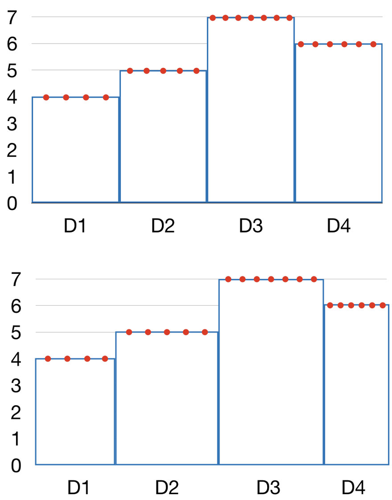

The second option, corresponding to setting `interp='linear'`, is also a random distribution over the range of values in the bin, but following a linear probability distribution constructed by fitting a line between two points determined as the average of the number of particles in the bin and the corresponding values on the neighbouring bins.

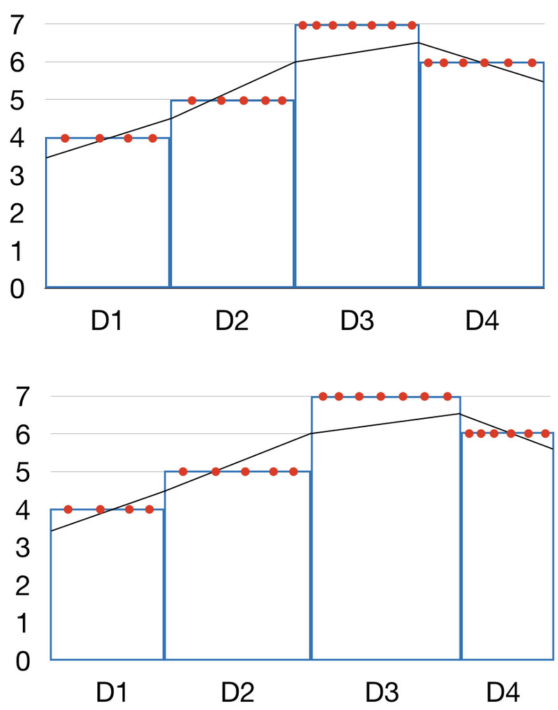

In practical terms, there is little difference between the `uniform` and `linear` options, and both methods correct in a satisfactory way the bias introduced by the binning structure.

## To do list

- Explain the option to use filters to remove unlikely particle size and velocity combinations, and the correction of the effective sampling area.
- Integrate the call to the perl script in a wrapper function in R.